# Risk Factor Analysis

## Outcome Variable

**Outcome Variable:** sstunted

## Predictor Variables

**Intervention Variable:** earlybf

**Adjustment Set:**

- arm
- sex
- W_mage
- meducyrs
- feducyrs
- hhwealth_quart
- hfoodsec
- W_mhtcm
- vagbrth
- W_gagebrth
- W_birthwt
- W_birthlen
- W_nrooms
- W_nchldlt5
- brthmon
- W_parity
- impfloor
- impsan
- safeh20
- delta_W_mage
- delta_meducyrs
- delta_feducyrs
- delta_hhwealth_quart
- delta_hfoodsec
- delta_W_mhtcm
- delta_vagbrth
- delta_W_gagebrth
- delta_W_birthwt
- delta_W_birthlen
- delta_W_nrooms
- delta_W_nchldlt5
- delta_brthmon
- delta_W_parity
- delta_impfloor
- delta_impsan
- delta_safeh20

## Stratifying Variables

The analysis was stratified on these variable(s):

- agecat
- studyid
- country

## Data Summary

| agecat | studyid | country | earlybf | sstunted | n_cell | n |
| --- | --- | --- | --- | --- | --- | --- |
| Birth | ki0047075b-MAL-ED | BANGLADESH | 0 | 0 | 90 | 256 |
| Birth | ki0047075b-MAL-ED | BANGLADESH | 0 | 1 | 7 | 256 |
| Birth | ki0047075b-MAL-ED | BANGLADESH | 1 | 0 | 157 | 256 |
| Birth | ki0047075b-MAL-ED | BANGLADESH | 1 | 1 | 2 | 256 |
| Birth | ki0047075b-MAL-ED | BRAZIL | 0 | 0 | 104 | 191 |
| Birth | ki0047075b-MAL-ED | BRAZIL | 0 | 1 | 4 | 191 |
| Birth | ki0047075b-MAL-ED | BRAZIL | 1 | 0 | 79 | 191 |
| Birth | ki0047075b-MAL-ED | BRAZIL | 1 | 1 | 4 | 191 |
| Birth | ki0047075b-MAL-ED | INDIA | 0 | 0 | 77 | 205 |
| Birth | ki0047075b-MAL-ED | INDIA | 0 | 1 | 4 | 205 |
| Birth | ki0047075b-MAL-ED | INDIA | 1 | 0 | 121 | 205 |
| Birth | ki0047075b-MAL-ED | INDIA | 1 | 1 | 3 | 205 |
| Birth | ki0047075b-MAL-ED | NEPAL | 0 | 0 | 90 | 173 |
| Birth | ki0047075b-MAL-ED | NEPAL | 0 | 1 | 4 | 173 |
| Birth | ki0047075b-MAL-ED | NEPAL | 1 | 0 | 77 | 173 |
| Birth | ki0047075b-MAL-ED | NEPAL | 1 | 1 | 2 | 173 |
| Birth | ki0047075b-MAL-ED | PERU | 0 | 0 | 68 | 287 |
| Birth | ki0047075b-MAL-ED | PERU | 0 | 1 | 5 | 287 |
| Birth | ki0047075b-MAL-ED | PERU | 1 | 0 | 211 | 287 |
| Birth | ki0047075b-MAL-ED | PERU | 1 | 1 | 3 | 287 |
| Birth | ki0047075b-MAL-ED | SOUTH AFRICA | 0 | 0 | 91 | 247 |
| Birth | ki0047075b-MAL-ED | SOUTH AFRICA | 0 | 1 | 1 | 247 |
| Birth | ki0047075b-MAL-ED | SOUTH AFRICA | 1 | 0 | 155 | 247 |
| Birth | ki0047075b-MAL-ED | SOUTH AFRICA | 1 | 1 | 0 | 247 |
| Birth | ki0047075b-MAL-ED | TANZANIA, UNITED REPUBLIC OF | 0 | 0 | 10 | 123 |
| Birth | ki0047075b-MAL-ED | TANZANIA, UNITED REPUBLIC OF | 0 | 1 | 2 | 123 |
| Birth | ki0047075b-MAL-ED | TANZANIA, UNITED REPUBLIC OF | 1 | 0 | 107 | 123 |
| Birth | ki0047075b-MAL-ED | TANZANIA, UNITED REPUBLIC OF | 1 | 1 | 4 | 123 |
| Birth | ki1000109-EE | PAKISTAN | 0 | 0 | 2 | 4 |
| Birth | ki1000109-EE | PAKISTAN | 0 | 1 | 0 | 4 |

[output cut: 126 more lines]

The following strata were considered:

- agecat: 24 months, studyid: ki0047075b-MAL-ED, country: BANGLADESH
- agecat: 24 months, studyid: ki0047075b-MAL-ED, country: BRAZIL
- agecat: 24 months, studyid: ki0047075b-MAL-ED, country: INDIA
- agecat: 24 months, studyid: ki0047075b-MAL-ED, country: NEPAL
- agecat: 24 months, studyid: ki0047075b-MAL-ED, country: PERU
- agecat: 24 months, studyid: ki0047075b-MAL-ED, country: SOUTH AFRICA
- agecat: 24 months, studyid: ki0047075b-MAL-ED, country: TANZANIA, UNITED REPUBLIC OF
- agecat: 24 months, studyid: ki1017093c-NIH-Crypto, country: BANGLADESH
- agecat: 24 months, studyid: ki1113344-GMS-Nepal, country: NEPAL
- agecat: 24 months, studyid: ki1126311-ZVITAMBO, country: ZIMBABWE
- agecat: 24 months, studyid: kiGH5241-JiVitA-3, country: BANGLADESH
- agecat: 24 months, studyid: kiGH5241-JiVitA-4, country: BANGLADESH
- agecat: 6 months, studyid: ki0047075b-MAL-ED, country: BANGLADESH
- agecat: 6 months, studyid: ki0047075b-MAL-ED, country: BRAZIL
- agecat: 6 months, studyid: ki0047075b-MAL-ED, country: INDIA
- agecat: 6 months, studyid: ki0047075b-MAL-ED, country: NEPAL
- agecat: 6 months, studyid: ki0047075b-MAL-ED, country: PERU
- agecat: 6 months, studyid: ki0047075b-MAL-ED, country: SOUTH AFRICA
- agecat: 6 months, studyid: ki0047075b-MAL-ED, country: TANZANIA, UNITED REPUBLIC OF
- agecat: 6 months, studyid: ki1000109-EE, country: PAKISTAN
- agecat: 6 months, studyid: ki1000304b-SAS-CompFeed, country: INDIA
- agecat: 6 months, studyid: ki1017093c-NIH-Crypto, country: BANGLADESH
- agecat: 6 months, studyid: ki1113344-GMS-Nepal, country: NEPAL
- agecat: 6 months, studyid: ki1126311-ZVITAMBO, country: ZIMBABWE
- agecat: 6 months, studyid: kiGH5241-JiVitA-3, country: BANGLADESH
- agecat: 6 months, studyid: kiGH5241-JiVitA-4, country: BANGLADESH
- agecat: Birth, studyid: ki0047075b-MAL-ED, country: BANGLADESH
- agecat: Birth, studyid: ki0047075b-MAL-ED, country: BRAZIL
- agecat: Birth, studyid: ki0047075b-MAL-ED, country: INDIA
- agecat: Birth, studyid: ki0047075b-MAL-ED, country: NEPAL
- agecat: Birth, studyid: ki0047075b-MAL-ED, country: PERU
- agecat: Birth, studyid: ki0047075b-MAL-ED, country: SOUTH AFRICA
- agecat: Birth, studyid: ki0047075b-MAL-ED, country: TANZANIA, UNITED REPUBLIC OF
- agecat: Birth, studyid: ki1000109-EE, country: PAKISTAN
- agecat: Birth, studyid: ki1000304b-SAS-CompFeed, country: INDIA
- agecat: Birth, studyid: ki1017093c-NIH-Crypto, country: BANGLADESH
- agecat: Birth, studyid: ki1126311-ZVITAMBO, country: ZIMBABWE
- agecat: Birth, studyid: kiGH5241-JiVitA-3, country: BANGLADESH
- agecat: Birth, studyid: kiGH5241-JiVitA-4, country: BANGLADESH

### Dropped Strata

Some strata were dropped due to rare outcomes:

- agecat: Birth, studyid: ki0047075b-MAL-ED, country: BANGLADESH
- agecat: Birth, studyid: ki0047075b-MAL-ED, country: BRAZIL
- agecat: Birth, studyid: ki0047075b-MAL-ED, country: INDIA
- agecat: Birth, studyid: ki0047075b-MAL-ED, country: NEPAL
- agecat: Birth, studyid: ki0047075b-MAL-ED, country: PERU
- agecat: Birth, studyid: ki0047075b-MAL-ED, country: SOUTH AFRICA
- agecat: Birth, studyid: ki0047075b-MAL-ED, country: TANZANIA, UNITED REPUBLIC OF
- agecat: Birth, studyid: ki1000109-EE, country: PAKISTAN
- agecat: Birth, studyid: ki1000304b-SAS-CompFeed, country: INDIA
- agecat: Birth, studyid: ki1017093c-NIH-Crypto, country: BANGLADESH
- agecat: 6 months, studyid: ki0047075b-MAL-ED, country: BANGLADESH
- agecat: 6 months, studyid: ki0047075b-MAL-ED, country: BRAZIL
- agecat: 6 months, studyid: ki0047075b-MAL-ED, country: INDIA
- agecat: 6 months, studyid: ki0047075b-MAL-ED, country: NEPAL
- agecat: 6 months, studyid: ki0047075b-MAL-ED, country: PERU
- agecat: 6 months, studyid: ki0047075b-MAL-ED, country: SOUTH AFRICA
- agecat: 6 months, studyid: ki1017093c-NIH-Crypto, country: BANGLADESH
- agecat: 24 months, studyid: ki0047075b-MAL-ED, country: BRAZIL
- agecat: 24 months, studyid: ki0047075b-MAL-ED, country: NEPAL
- agecat: 24 months, studyid: ki0047075b-MAL-ED, country: PERU
- agecat: 24 months, studyid: ki1017093c-NIH-Crypto, country: BANGLADESH
- agecat: 24 months, studyid: kiGH5241-JiVitA-3, country: BANGLADESH

## Methods Detail

We’re interested in the causal parameters $E[Y_a]$ for all values of $a \in \mathcal{A}$. These parameters represent the mean outcome if, possibly contrary to fact, we intervened to set all units to have $A=a$. Under the randomization and positivity assumptions, these are identified by the statistical parameters $\psi_a=E_W[E_{Y|A,W}(Y|A=a,W)]$. In addition, we’re interested in the mean of $Y$, $E[Y]$ under no intervention (the observed mean). We will estimate these parameters by using SuperLearner to fit the relevant likelihood factors – $E_{Y|A,W}(Y|A=a,W)$ and $p(A=a|W)$, and then updating our likelihood fit using a joint TMLE.

For unadjusted analyses ($W=\{\}$), initial likelihoods were estimated using Lrnr_glm to estimate the simple $E(Y|A)$ and Lrnr_mean to estimate $p(A)$. For adjusted analyses, a small library containing Lrnr_glmnet, Lrnr_xgboost, and Lrnr_mean was used.

Having estimated these parameters, we will then use the delta method to estimate relative risks and attributable risks relative to a prespecified baseline level of $A$.

# Results Detail

## Results Plots

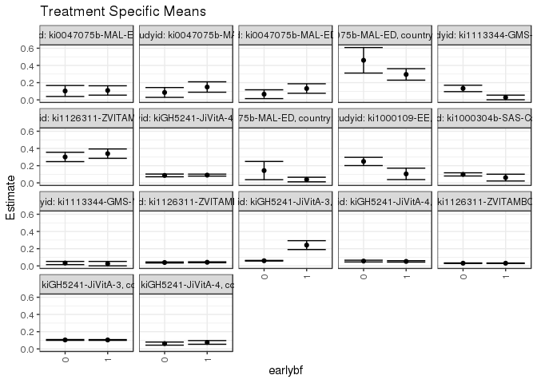

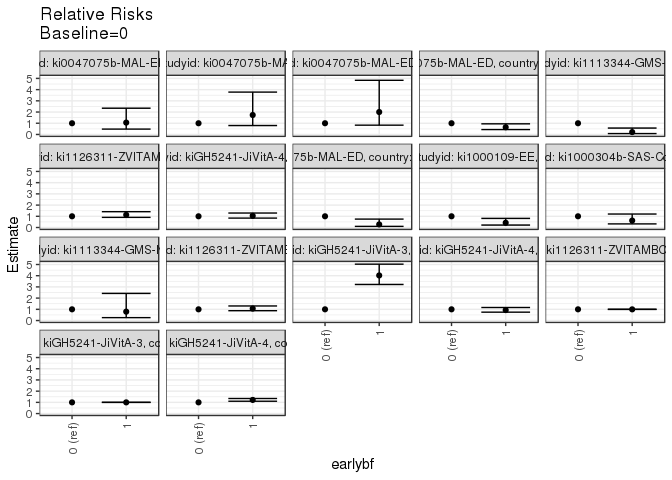

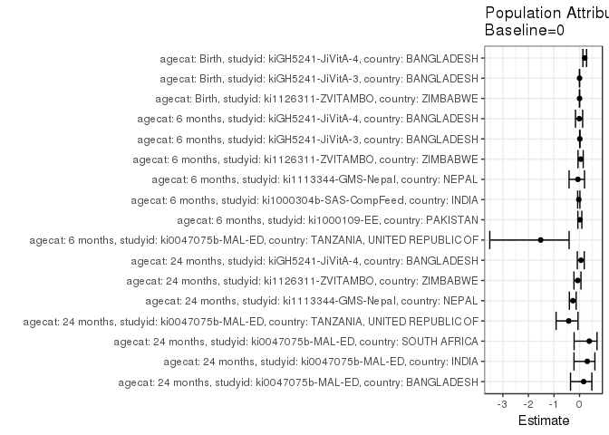

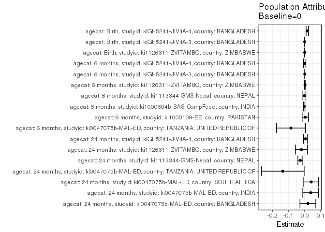

## Results Table

### Parameter: TSM

| agecat | studyid | country | intervention_level | baseline_level | estimate | ci_lower | ci_upper |
| --- | --- | --- | --- | --- | --- | --- | --- |
| Birth | ki1126311-ZVITAMBO | ZIMBABWE | 0 | NA | 0.0312315 | 0.0281606 | 0.0343025 |
| Birth | ki1126311-ZVITAMBO | ZIMBABWE | 1 | NA | 0.0311587 | 0.0280949 | 0.0342225 |
| Birth | kiGH5241-JiVitA-3 | BANGLADESH | 0 | NA | 0.1041897 | 0.0995097 | 0.1088696 |
| Birth | kiGH5241-JiVitA-3 | BANGLADESH | 1 | NA | 0.1040897 | 0.0994151 | 0.1087642 |
| Birth | kiGH5241-JiVitA-4 | BANGLADESH | 0 | NA | 0.0618456 | 0.0437720 | 0.0799191 |
| Birth | kiGH5241-JiVitA-4 | BANGLADESH | 1 | NA | 0.0752737 | 0.0538664 | 0.0966810 |
| 6 months | ki0047075b-MAL-ED | TANZANIA, UNITED REPUBLIC OF | 0 | NA | 0.1428571 | 0.0368142 | 0.2489001 |
| 6 months | ki0047075b-MAL-ED | TANZANIA, UNITED REPUBLIC OF | 1 | NA | 0.0390244 | 0.0124614 | 0.0655873 |
| 6 months | ki1000109-EE | PAKISTAN | 0 | NA | 0.2490519 | 0.2011767 | 0.2969270 |
| 6 months | ki1000109-EE | PAKISTAN | 1 | NA | 0.1043012 | 0.0379227 | 0.1706798 |
| 6 months | ki1000304b-SAS-CompFeed | INDIA | 0 | NA | 0.0985460 | 0.0798882 | 0.1172039 |
| 6 months | ki1000304b-SAS-CompFeed | INDIA | 1 | NA | 0.0612245 | 0.0218241 | 0.1006248 |
| 6 months | ki1113344-GMS-Nepal | NEPAL | 0 | NA | 0.0334262 | 0.0148144 | 0.0520380 |
| 6 months | ki1113344-GMS-Nepal | NEPAL | 1 | NA | 0.0264901 | 0.0008513 | 0.0521289 |
| 6 months | ki1126311-ZVITAMBO | ZIMBABWE | 0 | NA | 0.0394580 | 0.0333962 | 0.0455198 |
| 6 months | ki1126311-ZVITAMBO | ZIMBABWE | 1 | NA | 0.0420730 | 0.0363625 | 0.0477835 |
| 6 months | kiGH5241-JiVitA-3 | BANGLADESH | 0 | NA | 0.0600008 | 0.0561544 | 0.0638472 |
| 6 months | kiGH5241-JiVitA-3 | BANGLADESH | 1 | NA | 0.2413811 | 0.1900049 | 0.2927572 |
| 6 months | kiGH5241-JiVitA-4 | BANGLADESH | 0 | NA | 0.0561623 | 0.0459425 | 0.0663822 |
| 6 months | kiGH5241-JiVitA-4 | BANGLADESH | 1 | NA | 0.0523514 | 0.0443119 | 0.0603909 |
| 24 months | ki0047075b-MAL-ED | BANGLADESH | 0 | NA | 0.1032962 | 0.0396687 | 0.1669237 |
| 24 months | ki0047075b-MAL-ED | BANGLADESH | 1 | NA | 0.1094260 | 0.0551747 | 0.1636773 |
| 24 months | ki0047075b-MAL-ED | INDIA | 0 | NA | 0.0860215 | 0.0289083 | 0.1431348 |
| 24 months | ki0047075b-MAL-ED | INDIA | 1 | NA | 0.1492537 | 0.0887869 | 0.2097205 |
| 24 months | ki0047075b-MAL-ED | SOUTH AFRICA | 0 | NA | 0.0659341 | 0.0148369 | 0.1170313 |
| 24 months | ki0047075b-MAL-ED | SOUTH AFRICA | 1 | NA | 0.1319444 | 0.0765505 | 0.1873384 |
| 24 months | ki0047075b-MAL-ED | TANZANIA, UNITED REPUBLIC OF | 0 | NA | 0.4596626 | 0.3115212 | 0.6078039 |
| 24 months | ki0047075b-MAL-ED | TANZANIA, UNITED REPUBLIC OF | 1 | NA | 0.2954209 | 0.2289528 | 0.3618890 |
| 24 months | ki1113344-GMS-Nepal | NEPAL | 0 | NA | 0.1327782 | 0.0955148 | 0.1700416 |
| 24 months | ki1113344-GMS-Nepal | NEPAL | 1 | NA | 0.0281262 | 0.0014156 | 0.0548368 |
| 24 months | ki1126311-ZVITAMBO | ZIMBABWE | 0 | NA | 0.3011758 | 0.2471276 | 0.3552241 |
| 24 months | ki1126311-ZVITAMBO | ZIMBABWE | 1 | NA | 0.3397036 | 0.2854343 | 0.3939729 |
| 24 months | kiGH5241-JiVitA-4 | BANGLADESH | 0 | NA | 0.0868067 | 0.0710651 | 0.1025484 |
| 24 months | kiGH5241-JiVitA-4 | BANGLADESH | 1 | NA | 0.0902120 | 0.0788927 | 0.1015313 |

### Parameter: E(Y)

| agecat | studyid | country | intervention_level | baseline_level | estimate | ci_lower | ci_upper |
| --- | --- | --- | --- | --- | --- | --- | --- |
| Birth | ki1126311-ZVITAMBO | ZIMBABWE | NA | NA | 0.0312525 | 0.0281798 | 0.0343253 |
| Birth | kiGH5241-JiVitA-3 | BANGLADESH | NA | NA | 0.1041912 | 0.0995112 | 0.1088712 |
| Birth | kiGH5241-JiVitA-4 | BANGLADESH | NA | NA | 0.0778589 | 0.0559066 | 0.0998111 |
| 6 months | ki0047075b-MAL-ED | TANZANIA, UNITED REPUBLIC OF | NA | NA | 0.0566802 | 0.0277850 | 0.0855754 |
| 6 months | ki1000109-EE | PAKISTAN | NA | NA | 0.2526882 | 0.2084696 | 0.2969067 |
| 6 months | ki1000304b-SAS-CompFeed | INDIA | NA | NA | 0.0958084 | 0.0774939 | 0.1141229 |
| 6 months | ki1113344-GMS-Nepal | NEPAL | NA | NA | 0.0313725 | 0.0162285 | 0.0465166 |
| 6 months | ki1126311-ZVITAMBO | ZIMBABWE | NA | NA | 0.0414121 | 0.0368615 | 0.0459627 |
| 6 months | kiGH5241-JiVitA-3 | BANGLADESH | NA | NA | 0.0606665 | 0.0568133 | 0.0645198 |
| 6 months | kiGH5241-JiVitA-4 | BANGLADESH | NA | NA | 0.0556496 | 0.0487560 | 0.0625432 |
| 24 months | ki0047075b-MAL-ED | BANGLADESH | NA | NA | 0.1232227 | 0.0787669 | 0.1676786 |
| 24 months | ki0047075b-MAL-ED | INDIA | NA | NA | 0.1233480 | 0.0804760 | 0.1662200 |
| 24 months | ki0047075b-MAL-ED | SOUTH AFRICA | NA | NA | 0.1063830 | 0.0668780 | 0.1458880 |
| 24 months | ki0047075b-MAL-ED | TANZANIA, UNITED REPUBLIC OF | NA | NA | 0.3224299 | 0.2596598 | 0.3852000 |
| 24 months | ki1113344-GMS-Nepal | NEPAL | NA | NA | 0.1054945 | 0.0772375 | 0.1337515 |
| 24 months | ki1126311-ZVITAMBO | ZIMBABWE | NA | NA | 0.2807018 | 0.2365565 | 0.3248470 |
| 24 months | kiGH5241-JiVitA-4 | BANGLADESH | NA | NA | 0.0921435 | 0.0826637 | 0.1016234 |

### Parameter: RR

| agecat | studyid | country | intervention_level | baseline_level | estimate | ci_lower | ci_upper |
| --- | --- | --- | --- | --- | --- | --- | --- |
| Birth | ki1126311-ZVITAMBO | ZIMBABWE | 0 | 0 | 1.0000000 | 1.0000000 | 1.0000000 |
| Birth | ki1126311-ZVITAMBO | ZIMBABWE | 1 | 0 | 0.9976672 | 0.9968191 | 0.9985159 |
| Birth | kiGH5241-JiVitA-3 | BANGLADESH | 0 | 0 | 1.0000000 | 1.0000000 | 1.0000000 |
| Birth | kiGH5241-JiVitA-3 | BANGLADESH | 1 | 0 | 0.9990400 | 0.9989792 | 0.9991007 |
| Birth | kiGH5241-JiVitA-4 | BANGLADESH | 0 | 0 | 1.0000000 | 1.0000000 | 1.0000000 |
| Birth | kiGH5241-JiVitA-4 | BANGLADESH | 1 | 0 | 1.2171245 | 1.1017454 | 1.3445866 |
| 6 months | ki0047075b-MAL-ED | TANZANIA, UNITED REPUBLIC OF | 0 | 0 | 1.0000000 | 1.0000000 | 1.0000000 |
| 6 months | ki0047075b-MAL-ED | TANZANIA, UNITED REPUBLIC OF | 1 | 0 | 0.2731707 | 0.0997790 | 0.7478755 |
| 6 months | ki1000109-EE | PAKISTAN | 0 | 0 | 1.0000000 | 1.0000000 | 1.0000000 |
| 6 months | ki1000109-EE | PAKISTAN | 1 | 0 | 0.4187933 | 0.2163451 | 0.8106855 |
| 6 months | ki1000304b-SAS-CompFeed | INDIA | 0 | 0 | 1.0000000 | 1.0000000 | 1.0000000 |
| 6 months | ki1000304b-SAS-CompFeed | INDIA | 1 | 0 | 0.6212780 | 0.3218794 | 1.1991644 |
| 6 months | ki1113344-GMS-Nepal | NEPAL | 0 | 0 | 1.0000000 | 1.0000000 | 1.0000000 |
| 6 months | ki1113344-GMS-Nepal | NEPAL | 1 | 0 | 0.7924945 | 0.2594562 | 2.4206303 |
| 6 months | ki1126311-ZVITAMBO | ZIMBABWE | 0 | 0 | 1.0000000 | 1.0000000 | 1.0000000 |
| 6 months | ki1126311-ZVITAMBO | ZIMBABWE | 1 | 0 | 1.0662737 | 0.8758193 | 1.2981441 |
| 6 months | kiGH5241-JiVitA-3 | BANGLADESH | 0 | 0 | 1.0000000 | 1.0000000 | 1.0000000 |
| 6 months | kiGH5241-JiVitA-3 | BANGLADESH | 1 | 0 | 4.0229618 | 3.2181731 | 5.0290091 |
| 6 months | kiGH5241-JiVitA-4 | BANGLADESH | 0 | 0 | 1.0000000 | 1.0000000 | 1.0000000 |
| 6 months | kiGH5241-JiVitA-4 | BANGLADESH | 1 | 0 | 0.9321446 | 0.7480339 | 1.1615699 |
| 24 months | ki0047075b-MAL-ED | BANGLADESH | 0 | 0 | 1.0000000 | 1.0000000 | 1.0000000 |
| 24 months | ki0047075b-MAL-ED | BANGLADESH | 1 | 0 | 1.0593419 | 0.4791091 | 2.3422753 |
| 24 months | ki0047075b-MAL-ED | INDIA | 0 | 0 | 1.0000000 | 1.0000000 | 1.0000000 |
| 24 months | ki0047075b-MAL-ED | INDIA | 1 | 0 | 1.7350746 | 0.7971338 | 3.7766357 |
| 24 months | ki0047075b-MAL-ED | SOUTH AFRICA | 0 | 0 | 1.0000000 | 1.0000000 | 1.0000000 |
| 24 months | ki0047075b-MAL-ED | SOUTH AFRICA | 1 | 0 | 2.0011574 | 0.8288967 | 4.8312785 |
| 24 months | ki0047075b-MAL-ED | TANZANIA, UNITED REPUBLIC OF | 0 | 0 | 1.0000000 | 1.0000000 | 1.0000000 |
| 24 months | ki0047075b-MAL-ED | TANZANIA, UNITED REPUBLIC OF | 1 | 0 | 0.6426908 | 0.4348669 | 0.9498342 |
| 24 months | ki1113344-GMS-Nepal | NEPAL | 0 | 0 | 1.0000000 | 1.0000000 | 1.0000000 |
| 24 months | ki1113344-GMS-Nepal | NEPAL | 1 | 0 | 0.2118287 | 0.0786335 | 0.5706392 |
| 24 months | ki1126311-ZVITAMBO | ZIMBABWE | 0 | 0 | 1.0000000 | 1.0000000 | 1.0000000 |
| 24 months | ki1126311-ZVITAMBO | ZIMBABWE | 1 | 0 | 1.1279245 | 0.9036165 | 1.4079133 |
| 24 months | kiGH5241-JiVitA-4 | BANGLADESH | 0 | 0 | 1.0000000 | 1.0000000 | 1.0000000 |
| 24 months | kiGH5241-JiVitA-4 | BANGLADESH | 1 | 0 | 1.0392281 | 0.8377235 | 1.2892023 |

### Parameter: PAR

| agecat | studyid | country | intervention_level | baseline_level | estimate | ci_lower | ci_upper |
| --- | --- | --- | --- | --- | --- | --- | --- |
| Birth | ki1126311-ZVITAMBO | ZIMBABWE | 0 | NA | 0.0000210 | 0.0000101 | 0.0000319 |
| Birth | kiGH5241-JiVitA-3 | BANGLADESH | 0 | NA | 0.0000015 | 0.0000008 | 0.0000022 |
| Birth | kiGH5241-JiVitA-4 | BANGLADESH | 0 | NA | 0.0160133 | 0.0087475 | 0.0232791 |
| 6 months | ki0047075b-MAL-ED | TANZANIA, UNITED REPUBLIC OF | 0 | NA | -0.0861770 | -0.1770384 | 0.0046844 |
| 6 months | ki1000109-EE | PAKISTAN | 0 | NA | 0.0036363 | -0.0160819 | 0.0233546 |
| 6 months | ki1000304b-SAS-CompFeed | INDIA | 0 | NA | -0.0027377 | -0.0068956 | 0.0014203 |
| 6 months | ki1113344-GMS-Nepal | NEPAL | 0 | NA | -0.0020536 | -0.0114380 | 0.0073307 |
| 6 months | ki1126311-ZVITAMBO | ZIMBABWE | 0 | NA | 0.0019541 | -0.0022651 | 0.0061733 |
| 6 months | kiGH5241-JiVitA-3 | BANGLADESH | 0 | NA | 0.0006657 | 0.0002671 | 0.0010643 |
| 6 months | kiGH5241-JiVitA-4 | BANGLADESH | 0 | NA | -0.0005127 | -0.0082842 | 0.0072587 |
| 24 months | ki0047075b-MAL-ED | BANGLADESH | 0 | NA | 0.0199266 | -0.0295914 | 0.0694445 |
| 24 months | ki0047075b-MAL-ED | INDIA | 0 | NA | 0.0373265 | -0.0119398 | 0.0865928 |
| 24 months | ki0047075b-MAL-ED | SOUTH AFRICA | 0 | NA | 0.0404489 | -0.0059137 | 0.0868115 |
| 24 months | ki0047075b-MAL-ED | TANZANIA, UNITED REPUBLIC OF | 0 | NA | -0.1372327 | -0.2708330 | -0.0036323 |
| 24 months | ki1113344-GMS-Nepal | NEPAL | 0 | NA | -0.0272837 | -0.0425826 | -0.0119847 |
| 24 months | ki1126311-ZVITAMBO | ZIMBABWE | 0 | NA | -0.0204741 | -0.0582474 | 0.0172992 |
| 24 months | kiGH5241-JiVitA-4 | BANGLADESH | 0 | NA | 0.0053368 | -0.0070232 | 0.0176969 |

### Parameter: PAF

| agecat | studyid | country | intervention_level | baseline_level | estimate | ci_lower | ci_upper |
| --- | --- | --- | --- | --- | --- | --- | --- |
| Birth | ki1126311-ZVITAMBO | ZIMBABWE | 0 | NA | 0.0006718 | 0.0003289 | 0.0010145 |
| Birth | kiGH5241-JiVitA-3 | BANGLADESH | 0 | NA | 0.0000144 | 0.0000077 | 0.0000212 |
| Birth | kiGH5241-JiVitA-4 | BANGLADESH | 0 | NA | 0.2056712 | 0.1316170 | 0.2734101 |
| 6 months | ki0047075b-MAL-ED | TANZANIA, UNITED REPUBLIC OF | 0 | NA | -1.5204082 | -3.5100985 | -0.4084964 |
| 6 months | ki1000109-EE | PAKISTAN | 0 | NA | 0.0143905 | -0.0667782 | 0.0893833 |
| 6 months | ki1000304b-SAS-CompFeed | INDIA | 0 | NA | -0.0285743 | -0.0734293 | 0.0144063 |
| 6 months | ki1113344-GMS-Nepal | NEPAL | 0 | NA | -0.0654596 | -0.4087367 | 0.1941687 |
| 6 months | ki1126311-ZVITAMBO | ZIMBABWE | 0 | NA | 0.0471870 | -0.0602247 | 0.1437168 |
| 6 months | kiGH5241-JiVitA-3 | BANGLADESH | 0 | NA | 0.0109731 | 0.0043921 | 0.0175105 |
| 6 months | kiGH5241-JiVitA-4 | BANGLADESH | 0 | NA | -0.0092137 | -0.1590343 | 0.1212406 |
| 24 months | ki0047075b-MAL-ED | BANGLADESH | 0 | NA | 0.1617116 | -0.3526038 | 0.4804633 |
| 24 months | ki0047075b-MAL-ED | INDIA | 0 | NA | 0.3026114 | -0.2166709 | 0.6002609 |
| 24 months | ki0047075b-MAL-ED | SOUTH AFRICA | 0 | NA | 0.3802198 | -0.2123749 | 0.6831611 |
| 24 months | ki0047075b-MAL-ED | TANZANIA, UNITED REPUBLIC OF | 0 | NA | -0.4256201 | -0.9164549 | -0.0604960 |
| 24 months | ki1113344-GMS-Nepal | NEPAL | 0 | NA | -0.2586265 | -0.3983517 | -0.1328628 |
| 24 months | ki1126311-ZVITAMBO | ZIMBABWE | 0 | NA | -0.0729389 | -0.2186198 | 0.0553265 |
| 24 months | kiGH5241-JiVitA-4 | BANGLADESH | 0 | NA | 0.0579185 | -0.0865439 | 0.1831739 |